# Introduction to Data Visualization

Updated September 03, 2020

## This session

In this session you will be introduced to:

## Introduction to Visualization

## Purpose of Visualization

## Data Visualization Framework

## The DataViz framework

[figure not shown]

Borner, K. (2015). [Atlas of knowledge: Anyone can map](http://scimaps.org/atlas2) MIT Press.

## 2. Data Scales

[figure not shown]

## 3. Analysis type

- When: Temporal Analysis / Timeseries, Statistics
- Where: Geospation Analysis
- What: Topical Data Analysis
- With whom: Network Analysis

## 4. Visualization: Types

[figure not shown]

## 4. Visualization: Reference System

[figure not shown]

## 5. Graphic Symbols

- Points
- Lines
- Linguistic symbols

## 6. Graphic variables

[figure not shown]

## Symbols & variables combined

[figure not shown]

## 7. Interactions

[figure not shown]

## Visualizing Variables & Relationships

## Summaries of One Variable: Continuous

Histogram for binner bars

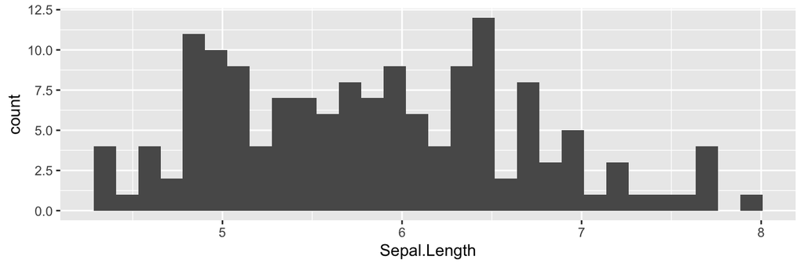

**Reference system:**

- x = Variable value
- y = Observation count
- Symbol = Bar

## Summaries of One Variable: Continuous

Alternative: Probability density function (PDF)

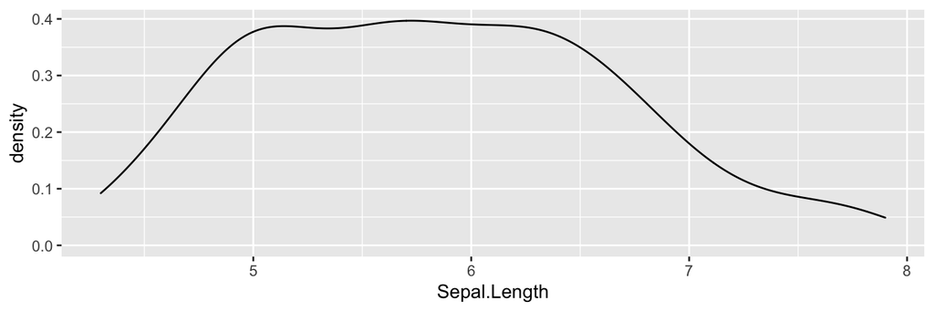

**Reference system:**

## Summaries of One Variable: Discrete

Barplot

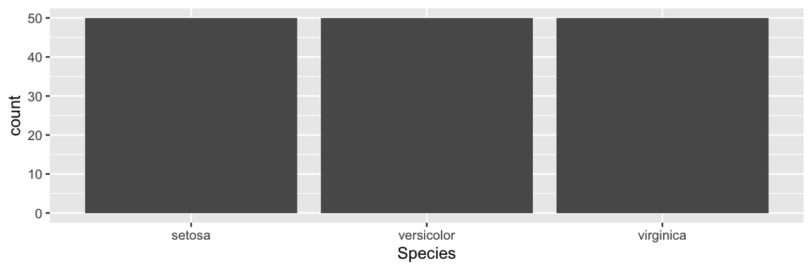

**Reference system:**

- x = Variable category
- y = Observation count
- Symbol = Bar

## Summaries of One Variable: Discrete

Barplot (stacked)

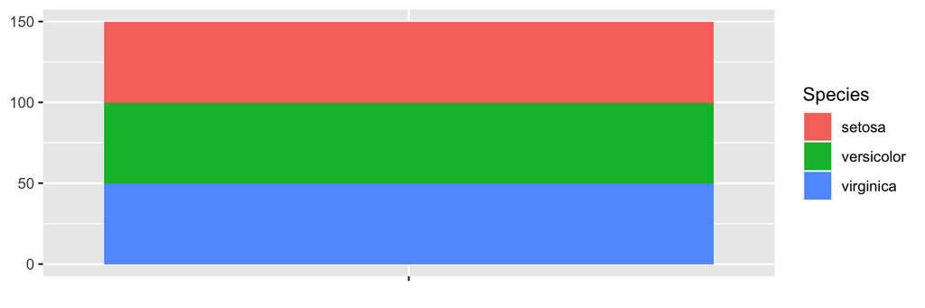

**Reference system:**

- y = Observation count
- Symbol = Bar
- Variable = Color

## Summaries of One Variable: Discrete

Pie Chart

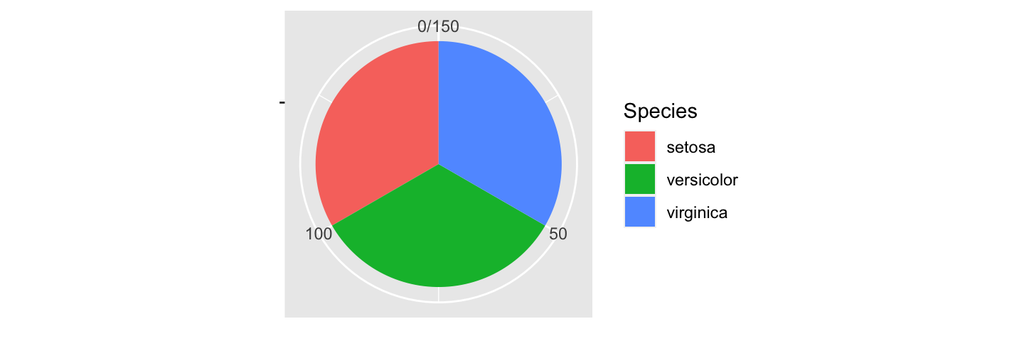

**Reference system:**

- y = Observation count
- Symbol = Bar (polar coordinates)
- Variable = Color

## Summarizing multiple variables jointly

Scatterplot (2 variables)

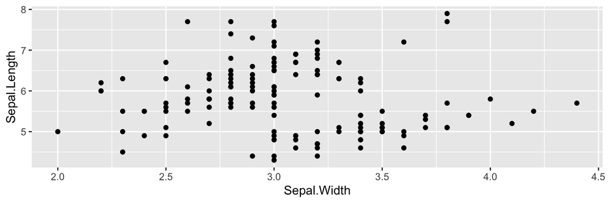

**Reference system:**

- y = Value Variable y
- x = Value variable x
- Symbol = Point

## Summarizing multiple variables jointly

Scatterplot (3 variables, 2c1d)

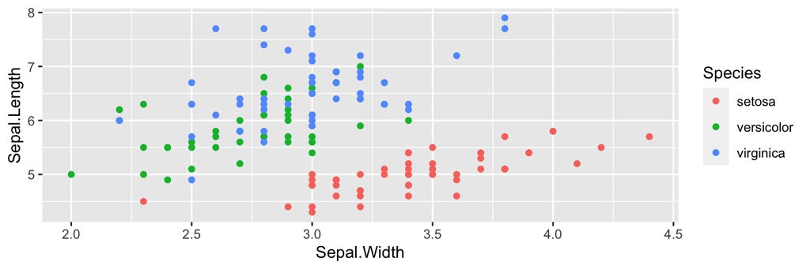

**Reference system:**

- y = Value Variable y
- x = Value variable x
- Symbol = Point
- Variable: Color (Species)

## Summarizing multiple variables jointly

Scatterplot (3 variables, 3c)

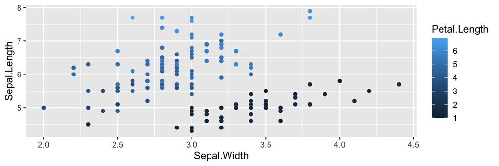

**Reference system:**

- y = Value Variable y
- x = Value variable x
- Symbol = Point
- Variable: Color (Petal.Lenght)

## Summarizing multiple variables jointly

Scatterplot (4 variables, 3c,1d)

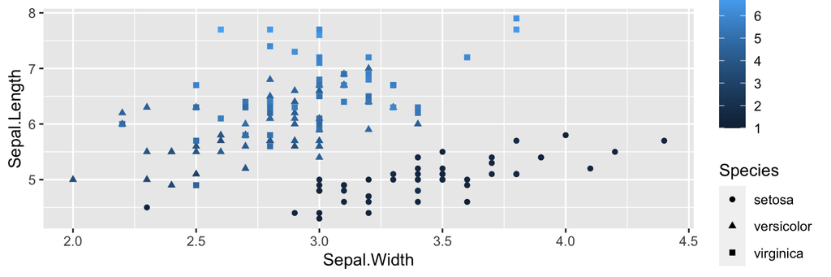

**Reference system:**

- y = Value Variable y
- x = Value variable x
- Symbol = Point
- Variable: Color (Petal.Lenght), Shape (Species)

## Statistical properties

Boxplot (Univariate distribution of multiple variables)

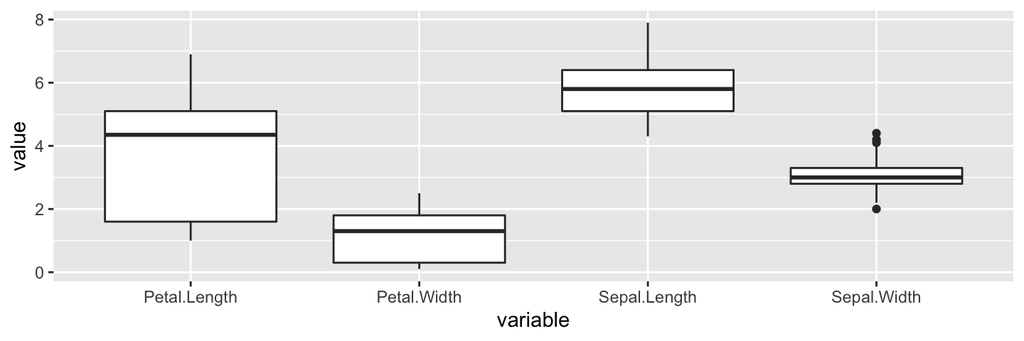

**Reference system:**

## Statistical properties

Correlation Matrix (bivariate distribution of multiple variables)

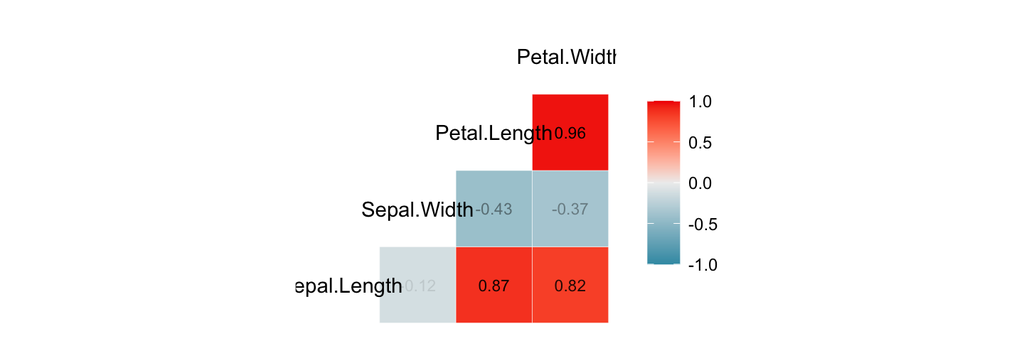

**Reference system:**

- y = Variable
- x = Variable
- VAriable: Color (Correlation)

## Statistical properties

Correlation Matrix (bivariate distribution of multiple variables)

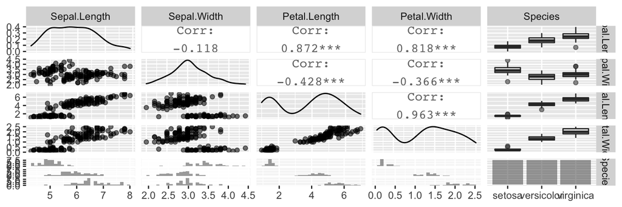

**Reference system:**